# Risk Factor Analysis

## Outcome Variable

**Outcome Variable:** ever_co

## Predictor Variables

**Intervention Variable:** hfoodsec

**Adjustment Set:**

unadjusted

## Stratifying Variables

The analysis was stratified on these variable(s):

- agecat
- studyid
- country

## Data Summary

| agecat | studyid | country | hfoodsec | ever_co | n_cell | n |
| --- | --- | --- | --- | --- | --- | --- |
| 0-24 months | GMS-Nepal | NEPAL | Food Secure | 0 | 339 | 663 |
| 0-24 months | GMS-Nepal | NEPAL | Food Secure | 1 | 132 | 663 |
| 0-24 months | GMS-Nepal | NEPAL | Mildly Food Insecure | 0 | 77 | 663 |
| 0-24 months | GMS-Nepal | NEPAL | Mildly Food Insecure | 1 | 28 | 663 |
| 0-24 months | GMS-Nepal | NEPAL | Food Insecure | 0 | 54 | 663 |
| 0-24 months | GMS-Nepal | NEPAL | Food Insecure | 1 | 33 | 663 |
| 0-24 months | MAL-ED | BANGLADESH | Food Secure | 0 | 135 | 194 |
| 0-24 months | MAL-ED | BANGLADESH | Food Secure | 1 | 26 | 194 |
| 0-24 months | MAL-ED | BANGLADESH | Mildly Food Insecure | 0 | 3 | 194 |
| 0-24 months | MAL-ED | BANGLADESH | Mildly Food Insecure | 1 | 1 | 194 |
| 0-24 months | MAL-ED | BANGLADESH | Food Insecure | 0 | 24 | 194 |
| 0-24 months | MAL-ED | BANGLADESH | Food Insecure | 1 | 5 | 194 |
| 0-24 months | MAL-ED | BRAZIL | Food Secure | 0 | 3 | 129 |
| 0-24 months | MAL-ED | BRAZIL | Food Secure | 1 | 0 | 129 |
| 0-24 months | MAL-ED | BRAZIL | Mildly Food Insecure | 0 | 11 | 129 |
| 0-24 months | MAL-ED | BRAZIL | Mildly Food Insecure | 1 | 0 | 129 |
| 0-24 months | MAL-ED | BRAZIL | Food Insecure | 0 | 112 | 129 |
| 0-24 months | MAL-ED | BRAZIL | Food Insecure | 1 | 3 | 129 |
| 0-24 months | MAL-ED | INDIA | Food Secure | 0 | 143 | 212 |
| 0-24 months | MAL-ED | INDIA | Food Secure | 1 | 47 | 212 |
| 0-24 months | MAL-ED | INDIA | Mildly Food Insecure | 0 | 5 | 212 |
| 0-24 months | MAL-ED | INDIA | Mildly Food Insecure | 1 | 0 | 212 |
| 0-24 months | MAL-ED | INDIA | Food Insecure | 0 | 14 | 212 |
| 0-24 months | MAL-ED | INDIA | Food Insecure | 1 | 3 | 212 |
| 0-24 months | MAL-ED | NEPAL | Food Secure | 0 | 86 | 128 |
| 0-24 months | MAL-ED | NEPAL | Food Secure | 1 | 8 | 128 |
| 0-24 months | MAL-ED | NEPAL | Mildly Food Insecure | 0 | 13 | 128 |
| 0-24 months | MAL-ED | NEPAL | Mildly Food Insecure | 1 | 2 | 128 |
| 0-24 months | MAL-ED | NEPAL | Food Insecure | 0 | 13 | 128 |
| 0-24 months | MAL-ED | NEPAL | Food Insecure | 1 | 6 | 128 |

[output cut: 132 more lines]

The following strata were considered:

- agecat: 0-24 months, studyid: GMS-Nepal, country: NEPAL
- agecat: 0-24 months, studyid: MAL-ED, country: BANGLADESH
- agecat: 0-24 months, studyid: MAL-ED, country: BRAZIL
- agecat: 0-24 months, studyid: MAL-ED, country: INDIA
- agecat: 0-24 months, studyid: MAL-ED, country: NEPAL
- agecat: 0-24 months, studyid: MAL-ED, country: PERU
- agecat: 0-24 months, studyid: MAL-ED, country: SOUTH AFRICA
- agecat: 0-24 months, studyid: NIH-Birth, country: BANGLADESH
- agecat: 0-24 months, studyid: NIH-Crypto, country: BANGLADESH
- agecat: 0-6 months, studyid: GMS-Nepal, country: NEPAL
- agecat: 0-6 months, studyid: MAL-ED, country: BANGLADESH
- agecat: 0-6 months, studyid: MAL-ED, country: BRAZIL
- agecat: 0-6 months, studyid: MAL-ED, country: INDIA
- agecat: 0-6 months, studyid: MAL-ED, country: NEPAL
- agecat: 0-6 months, studyid: MAL-ED, country: PERU
- agecat: 0-6 months, studyid: MAL-ED, country: SOUTH AFRICA
- agecat: 0-6 months, studyid: NIH-Birth, country: BANGLADESH
- agecat: 0-6 months, studyid: NIH-Crypto, country: BANGLADESH
- agecat: 6-24 months, studyid: GMS-Nepal, country: NEPAL
- agecat: 6-24 months, studyid: MAL-ED, country: BANGLADESH
- agecat: 6-24 months, studyid: MAL-ED, country: BRAZIL
- agecat: 6-24 months, studyid: MAL-ED, country: INDIA
- agecat: 6-24 months, studyid: MAL-ED, country: NEPAL
- agecat: 6-24 months, studyid: MAL-ED, country: PERU
- agecat: 6-24 months, studyid: MAL-ED, country: SOUTH AFRICA
- agecat: 6-24 months, studyid: NIH-Birth, country: BANGLADESH
- agecat: 6-24 months, studyid: NIH-Crypto, country: BANGLADESH

### Dropped Strata

Some strata were dropped due to rare outcomes:

- agecat: 0-24 months, studyid: MAL-ED, country: BANGLADESH
- agecat: 0-24 months, studyid: MAL-ED, country: BRAZIL
- agecat: 0-24 months, studyid: MAL-ED, country: INDIA
- agecat: 0-24 months, studyid: MAL-ED, country: NEPAL
- agecat: 0-24 months, studyid: MAL-ED, country: PERU
- agecat: 0-24 months, studyid: MAL-ED, country: SOUTH AFRICA
- agecat: 0-6 months, studyid: GMS-Nepal, country: NEPAL
- agecat: 0-6 months, studyid: MAL-ED, country: BANGLADESH
- agecat: 0-6 months, studyid: MAL-ED, country: BRAZIL
- agecat: 0-6 months, studyid: MAL-ED, country: INDIA
- agecat: 0-6 months, studyid: MAL-ED, country: NEPAL
- agecat: 0-6 months, studyid: MAL-ED, country: PERU
- agecat: 0-6 months, studyid: MAL-ED, country: SOUTH AFRICA
- agecat: 0-6 months, studyid: NIH-Birth, country: BANGLADESH
- agecat: 0-6 months, studyid: NIH-Crypto, country: BANGLADESH
- agecat: 6-24 months, studyid: MAL-ED, country: BANGLADESH
- agecat: 6-24 months, studyid: MAL-ED, country: BRAZIL
- agecat: 6-24 months, studyid: MAL-ED, country: INDIA
- agecat: 6-24 months, studyid: MAL-ED, country: NEPAL
- agecat: 6-24 months, studyid: MAL-ED, country: PERU
- agecat: 6-24 months, studyid: MAL-ED, country: SOUTH AFRICA

## Methods Detail

We’re interested in the causal parameters $E[Y_a]$ for all values of $a \in \mathcal{A}$. These parameters represent the mean outcome if, possibly contrary to fact, we intervened to set all units to have $A=a$. Under the randomization and positivity assumptions, these are identified by the statistical parameters $\psi_a=E_W[E_{Y|A,W}(Y|A=a,W)]$. In addition, we’re interested in the mean of $Y$, $E[Y]$ under no intervention (the observed mean). We will estimate these parameters by using SuperLearner to fit the relevant likelihood factors – $E_{Y|A,W}(Y|A=a,W)$ and $p(A=a|W)$, and then updating our likelihood fit using a joint TMLE.

For unadjusted analyses ($W=\{\}$), initial likelihoods were estimated using Lrnr_glm to estimate the simple $E(Y|A)$ and Lrnr_mean to estimate $p(A)$. For adjusted analyses, a small library containing Lrnr_glmnet, Lrnr_xgboost, and Lrnr_mean was used.

Having estimated these parameters, we will then use the delta method to estimate relative risks and attributable risks relative to a prespecified baseline level of $A$.

# Results Detail

## Results Plots

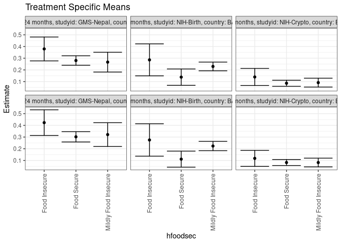

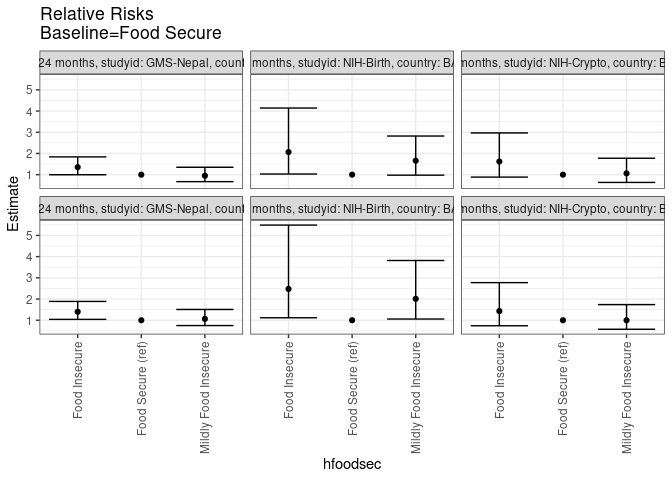

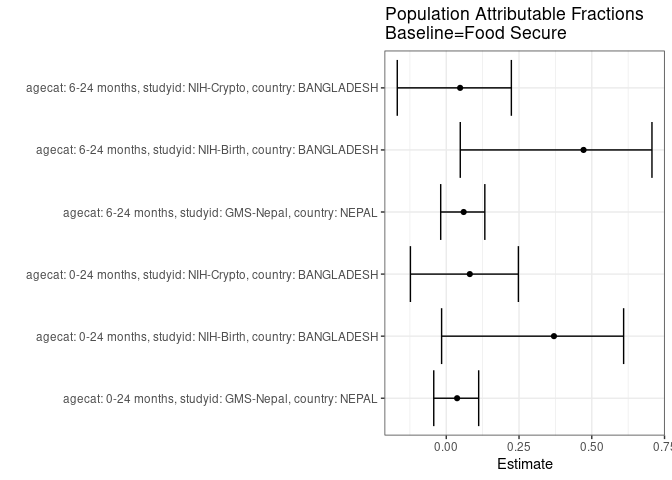

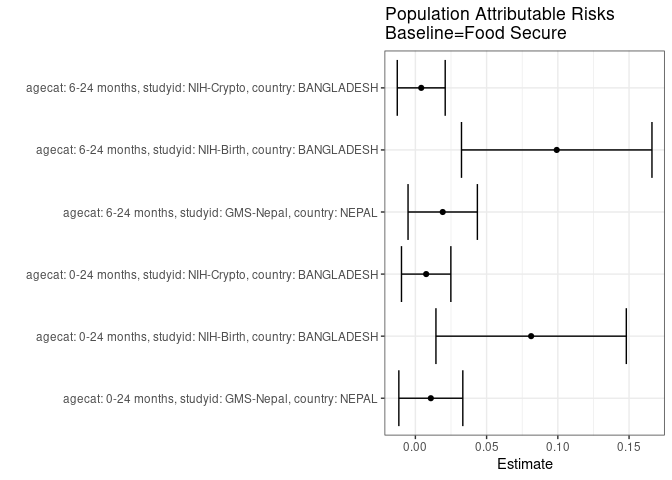

## Results Table

### Parameter: TSM

| agecat | studyid | country | intervention_level | baseline_level | estimate | ci_lower | ci_upper |
| --- | --- | --- | --- | --- | --- | --- | --- |
| 0-24 months | GMS-Nepal | NEPAL | Food Secure | NA | 0.2802548 | 0.2396636 | 0.3208459 |
| 0-24 months | GMS-Nepal | NEPAL | Mildly Food Insecure | NA | 0.2666667 | 0.1820187 | 0.3513146 |
| 0-24 months | GMS-Nepal | NEPAL | Food Insecure | NA | 0.3793103 | 0.2772750 | 0.4813457 |
| 0-24 months | NIH-Birth | BANGLADESH | Food Secure | NA | 0.1382979 | 0.0684555 | 0.2081402 |
| 0-24 months | NIH-Birth | BANGLADESH | Mildly Food Insecure | NA | 0.2295082 | 0.1921686 | 0.2668478 |
| 0-24 months | NIH-Birth | BANGLADESH | Food Insecure | NA | 0.2857143 | 0.1489812 | 0.4224474 |
| 0-24 months | NIH-Crypto | BANGLADESH | Food Secure | NA | 0.0860927 | 0.0602451 | 0.1119403 |
| 0-24 months | NIH-Crypto | BANGLADESH | Mildly Food Insecure | NA | 0.0913242 | 0.0531465 | 0.1295019 |
| 0-24 months | NIH-Crypto | BANGLADESH | Food Insecure | NA | 0.1395349 | 0.0662535 | 0.2128163 |
| 6-24 months | GMS-Nepal | NEPAL | Food Secure | NA | 0.3019324 | 0.2576704 | 0.3461943 |
| 6-24 months | GMS-Nepal | NEPAL | Mildly Food Insecure | NA | 0.3209877 | 0.2192298 | 0.4227455 |
| 6-24 months | GMS-Nepal | NEPAL | Food Insecure | NA | 0.4230769 | 0.3133410 | 0.5328128 |
| 6-24 months | NIH-Birth | BANGLADESH | Food Secure | NA | 0.1111111 | 0.0426082 | 0.1796140 |
| 6-24 months | NIH-Birth | BANGLADESH | Mildly Food Insecure | NA | 0.2232779 | 0.1834613 | 0.2630945 |
| 6-24 months | NIH-Birth | BANGLADESH | Food Insecure | NA | 0.2750000 | 0.1364985 | 0.4135015 |
| 6-24 months | NIH-Crypto | BANGLADESH | Food Secure | NA | 0.0821918 | 0.0564524 | 0.1079312 |
| 6-24 months | NIH-Crypto | BANGLADESH | Mildly Food Insecure | NA | 0.0821256 | 0.0446980 | 0.1195532 |
| 6-24 months | NIH-Crypto | BANGLADESH | Food Insecure | NA | 0.1176471 | 0.0491064 | 0.1861877 |

### Parameter: E(Y)

| agecat | studyid | country | intervention_level | baseline_level | estimate | ci_lower | ci_upper |
| --- | --- | --- | --- | --- | --- | --- | --- |
| 0-24 months | GMS-Nepal | NEPAL | NA | NA | 0.2911011 | 0.2564965 | 0.3257056 |
| 0-24 months | NIH-Birth | BANGLADESH | NA | NA | 0.2195513 | 0.1870467 | 0.2520558 |
| 0-24 months | NIH-Crypto | BANGLADESH | NA | NA | 0.0936675 | 0.0729118 | 0.1144233 |
| 6-24 months | GMS-Nepal | NEPAL | NA | NA | 0.3211169 | 0.2828539 | 0.3593799 |
| 6-24 months | NIH-Birth | BANGLADESH | NA | NA | 0.2103321 | 0.1759902 | 0.2446740 |
| 6-24 months | NIH-Crypto | BANGLADESH | NA | NA | 0.0863014 | 0.0659171 | 0.1066856 |

### Parameter: RR

| agecat | studyid | country | intervention_level | baseline_level | estimate | ci_lower | ci_upper |
| --- | --- | --- | --- | --- | --- | --- | --- |
| 0-24 months | GMS-Nepal | NEPAL | Food Secure | Food Secure | 1.0000000 | 1.0000000 | 1.000000 |
| 0-24 months | GMS-Nepal | NEPAL | Mildly Food Insecure | Food Secure | 0.9515152 | 0.6712516 | 1.348795 |
| 0-24 months | GMS-Nepal | NEPAL | Food Insecure | Food Secure | 1.3534483 | 0.9971439 | 1.837069 |
| 0-24 months | NIH-Birth | BANGLADESH | Food Secure | Food Secure | 1.0000000 | 1.0000000 | 1.000000 |
| 0-24 months | NIH-Birth | BANGLADESH | Mildly Food Insecure | Food Secure | 1.6595208 | 0.9762421 | 2.821031 |
| 0-24 months | NIH-Birth | BANGLADESH | Food Insecure | Food Secure | 2.0659341 | 1.0302847 | 4.142625 |
| 0-24 months | NIH-Crypto | BANGLADESH | Food Secure | Food Secure | 1.0000000 | 1.0000000 | 1.000000 |
| 0-24 months | NIH-Crypto | BANGLADESH | Mildly Food Insecure | Food Secure | 1.0607657 | 0.6340080 | 1.774779 |
| 0-24 months | NIH-Crypto | BANGLADESH | Food Insecure | Food Secure | 1.6207513 | 0.8851020 | 2.967833 |
| 6-24 months | GMS-Nepal | NEPAL | Food Secure | Food Secure | 1.0000000 | 1.0000000 | 1.000000 |
| 6-24 months | GMS-Nepal | NEPAL | Mildly Food Insecure | Food Secure | 1.0631111 | 0.7497097 | 1.507524 |
| 6-24 months | GMS-Nepal | NEPAL | Food Insecure | Food Secure | 1.4012308 | 1.0402017 | 1.887564 |
| 6-24 months | NIH-Birth | BANGLADESH | Food Secure | Food Secure | 1.0000000 | 1.0000000 | 1.000000 |
| 6-24 months | NIH-Birth | BANGLADESH | Mildly Food Insecure | Food Secure | 2.0095012 | 1.0576908 | 3.817841 |
| 6-24 months | NIH-Birth | BANGLADESH | Food Insecure | Food Secure | 2.4750000 | 1.1164457 | 5.486720 |
| 6-24 months | NIH-Crypto | BANGLADESH | Food Secure | Food Secure | 1.0000000 | 1.0000000 | 1.000000 |
| 6-24 months | NIH-Crypto | BANGLADESH | Mildly Food Insecure | Food Secure | 0.9991948 | 0.5747808 | 1.736993 |
| 6-24 months | NIH-Crypto | BANGLADESH | Food Insecure | Food Secure | 1.4313725 | 0.7387504 | 2.773369 |

### Parameter: PAR

| agecat | studyid | country | intervention_level | baseline_level | estimate | ci_lower | ci_upper |
| --- | --- | --- | --- | --- | --- | --- | --- |
| 0-24 months | GMS-Nepal | NEPAL | Food Secure | NA | 0.0108463 | -0.0116064 | 0.0332990 |
| 0-24 months | NIH-Birth | BANGLADESH | Food Secure | NA | 0.0812534 | 0.0144338 | 0.1480730 |
| 0-24 months | NIH-Crypto | BANGLADESH | Food Secure | NA | 0.0075748 | -0.0097559 | 0.0249056 |
| 6-24 months | GMS-Nepal | NEPAL | Food Secure | NA | 0.0191846 | -0.0051505 | 0.0435197 |
| 6-24 months | NIH-Birth | BANGLADESH | Food Secure | NA | 0.0992210 | 0.0323673 | 0.1660747 |
| 6-24 months | NIH-Crypto | BANGLADESH | Food Secure | NA | 0.0041096 | -0.0127134 | 0.0209326 |

### Parameter: PAF

| agecat | studyid | country | intervention_level | baseline_level | estimate | ci_lower | ci_upper |
| --- | --- | --- | --- | --- | --- | --- | --- |
| 0-24 months | GMS-Nepal | NEPAL | Food Secure | NA | 0.0372595 | -0.0430157 | 0.1113564 |
| 0-24 months | NIH-Birth | BANGLADESH | Food Secure | NA | 0.3700885 | -0.0160266 | 0.6094704 |
| 0-24 months | NIH-Crypto | BANGLADESH | Food Secure | NA | 0.0808693 | -0.1232318 | 0.2478835 |
| 6-24 months | GMS-Nepal | NEPAL | Food Secure | NA | 0.0597432 | -0.0191371 | 0.1325183 |
| 6-24 months | NIH-Birth | BANGLADESH | Food Secure | NA | 0.4717349 | 0.0481092 | 0.7068319 |
| 6-24 months | NIH-Crypto | BANGLADESH | Food Secure | NA | 0.0476190 | -0.1683708 | 0.2236801 |